# Master Thesis

Marc Jerónimo Pérez y Ropero

## Background

- In my Internship I studied the current GRUD, particularly Mg, P and K
- Fertilizer requirement models imply $Y\sim STP + Clay$ & $P-\text{Export}\sim STP + Clay$
- Currently only stationery measurement of STP are considered
- Could a desorption kinext-model better explain the soil status and yield data?

[figure not shown]

  GRUD 2017

## Context

- LTE STYCS, all treatment conditions equal except P-fertilization, which is in 6 Levels, 3 were considered($P0$,$P100$,$P166$)
- 5 Sites regarded; Cadenazzo, Ellighausen, Rümlang-Altwi, Oensingen, Zürich-Reckenholz

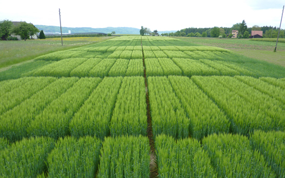

## Variable Introduction

**Soil Variables:**

- $P-CO_2$ & $P-AAE10$ stand for the GRUD STP-measurements in [$g~P/kg ~ Soil$]
- $k$($s^{-1}$) can be interpreted as the relative speed of desorption of orthophosphate of the net-desorption experiment
- $PS$($mg~P/L~H_2O$) is the equilibrium concentration of $PO_4^{3-}$ of the net-desorption experiment
- From the 0-20cm Horizon: Clay-, Silt-,$C_{org}$-content and pH

**Yield Variables:**

- For a year $X$ and crop $C$ $Y_{main-rel}$ stands for $Y_{main-rel}:=Y_C^{X}/mean(Y_C~\text{in year}~X~\text{in CH})$
- For every year:site:crop combination the yield was normalised using: $Y_\text{norm}:=Y/median(Y_{P166})$
- The P-Export was calculated as the P-Uptake of the main product
- The P-Balance was calculated as the difference $P_{Fertilized}-\text{P-Export}$

## Research Questions

- I: Is the method presented by Flossmann and Richter (1982) with the double extraction replicable with the soils from the STYCS-trial? predicting relative Yield, P-Export and P-Balance?
- II: How do GRUD-measurements of STP correlate to the soil properties $C_\text{org}$-content, clay-content, silt-content and pH?
- III: Are the kinetic coefficients $k$ and $PS$ ($k$ can be interpreted as the relative speed of desorption, $PS$ is the equilibrium concentration of $PO_4^{3-}$ of the observed desorption in the dried fine earth-water suspension 1:20 by weight) correlated to soil properties?
- IV: How well can current GRUD methods of STP ($P-CO_2$ & $P-AAE10$) predict the Yield-parameters, P-Export and P-Balance?
- V: Can the kinetic parameters $k$ & $PS$ of the net-release-kinetic of Orthophosphate improve the prediction of Yield-parameters, P-Export and P-Balance?

## Research Question I

# Question II * III

The following random structure was chosen:

`(1|year) + (1|Site) + (1|Site:block) + (Treatment|Site)`

## Do P-CO2, P_AAE10, k and PS correlate with soil characteristics?

Coefficient Table for Soil covariates. Significant codes: 0 ‘***’ 0.001 ‘**’ 0.01 ‘*’ 0.05

| Covariate | PS | k | log.k.PS. | k.log.PS. | CO2 | AAE10 | fail |
| --- | --- | --- | --- | --- | --- | --- | --- |
| (Intercept) | ***-4.271 | -0.159 | ***-6.881 | 0.049 | -1.092 | -0.043 | ***124.095 |
| k |  |  |  |  |  |  | 72.766 |
| k:log(PS) |  |  |  |  |  |  | 36.002 |
| log(PS) |  |  |  |  |  |  | 1.355 |
| soil_0_20_clay | 0.012 | -0.004 | -0.007 | * 0.012 | -0.016 | 0.010 |  |
| soil_0_20_Corg | ***0.567 | -0.003 | 0.216 | 0.062 | * 0.490 | * 0.379 |  |
| soil_0_20_pH_H2O | -0.003 | ** 0.035 | 0.174 | ** -0.086 | 0.067 | * 0.148 |  |
| soil_0_20_silt | -0.021 | ** 0.007 | 0.013 | * -0.019 | -0.036 | 0.015 |  |
| TreatmentP100 | ***1.063 | 0.002 | ** 1.056 | ***0.195 | ** 0.703 | ***0.744 |  |
| TreatmentP166 | ***1.841 | -0.031 | ***1.633 | ***0.412 | ***1.271 | ***1.157 |  |
| R2m | 0.858 | 0.399 | 0.666 | 0.678 | 0.661 | 0.519 | 0.029 |
| R2c | 0.950 | 0.697 | 0.912 | 0.833 | 0.782 | 0.905 | 0.800 |

# Question IV & V

## Yield model summary:

Coefficient Table for Ynorm and Yrel. Significant codes: 0 ‘***’ 0.001 ‘**’ 0.01 ‘*’ 0.05

| Covariate | CO2_Ynorm | AAE10_Ynorm | Grud_Ynorm | CO2_Yrel | AAE10_Yrel | Grud_Yrel | Kin_Ynorm | Kin_Yrel |
| --- | --- | --- | --- | --- | --- | --- | --- | --- |
| (Intercept) | ***1.038 | ***0.463 | ***0.970 | ***98.786 | ***67.321 | ***70.659 | ***0.881 | ***124.095 |
| k |  |  |  |  |  |  | * 1.558 | 72.766 |
| k:log(PS) |  |  |  |  |  |  | ** 0.680 | 36.002 |
| log(PS) |  |  |  |  |  |  | -0.024 | 1.355 |
| log(soil_0_20_P_AAE10) |  | ***0.140 | 0.020 |  | ** 8.788 | 8.099 |  |  |
| log(soil_0_20_P_CO2) | ***0.163 |  | 0.095 | 6.190 |  | 1.155 |  |  |
| log(soil_0_20_P_CO2):log(soil_0_20_P_AAE10) |  |  | 0.021 |  |  |  |  |  |
| TreatmentP100 |  |  |  | 6.546 | 4.352 | 4.062 |  |  |
| TreatmentP166 |  |  |  | 4.838 | 2.232 | 1.599 |  |  |
| R2m | 0.226 | 0.203 | 0.224 | 0.080 | 0.098 | 0.098 | 0.194 | 0.029 |
| R2c | 0.432 | 0.445 | 0.439 | 0.576 | 0.582 | 0.582 | 0.409 | 0.800 |

## P-Export model summary:

Coefficient Table for P-Export. Significant codes: 0 ‘***’ 0.001 ‘**’ 0.01 ‘*’ 0.05

| Covariate | CO2_Pexport | AAE10_Pexport | Grud_Pexport | Kin_Pexport |
| --- | --- | --- | --- | --- |
| (Intercept) | ***24.761 | 9.594 | ** 24.908 | ***36.785 |
| k |  |  |  | 23.494 |
| k:log(PS) |  |  |  | 10.824 |
| log(PS) |  |  |  | 2.380 |
| log(soil_0_20_P_AAE10) |  | 3.385 | -0.043 |  |
| log(soil_0_20_P_CO2) | ** 4.757 |  | * 4.783 |  |
| TreatmentP100 | 2.085 | 3.022 | 2.097 |  |
| TreatmentP166 | 1.150 | 3.338 | 1.166 |  |
| R2m | 0.076 | 0.074 | 0.076 | 0.039 |
| R2c | 0.577 | 0.542 | 0.577 | 0.751 |

## P-balance model summary:

Coefficient Table for P-Balance. Significant codes: 0 ‘***’ 0.001 ‘**’ 0.01 ‘*’ 0.05

| Covariate | CO2_Pbalance | AAE10_Pbalance | Grud_Pbalance | Kin_Pbalance |
| --- | --- | --- | --- | --- |
| (Intercept) | ***-24.532 | -8.080 | * -24.460 | ***45.816 |
| k |  |  |  | 81.169 |
| k:log(PS) |  |  |  | 31.798 |
| log(PS) |  |  |  | ***19.365 |
| log(soil_0_20_P_AAE10) |  | -3.680 | -0.022 |  |
| log(soil_0_20_P_CO2) | * -5.148 |  | -5.138 |  |
| TreatmentP100 | ***30.965 | ***29.964 | ***30.974 |  |
| TreatmentP166 | ***54.052 | ***51.704 | ***54.066 |  |
| R2m | 0.628 | 0.641 | 0.627 | 0.521 |
| R2c | 0.808 | 0.798 | 0.807 | 0.784 |